# PA1 Assignments

IoA

17 September 2019

# Assignment 1 # same do with Ozone data base in R

### a) Find a historically interesting or valuable data set, and explain the variables. What is the dependent (target) variable and Independent variable(s)

We have choosen the abalone dataset which provides the details of sea snails, including its weight, gender, height and number of rings(age=no of rings+1.5); We are interested in predicting the whole weight using the variable number rings. So Whole_weight is the dependent variable and rings is independent variable.

```r
# read data
ab<- read.csv("abalone_csv.csv",header=TRUE,col.names = c("Sex","Length","Dia","Height","Whl_weight","Shucked_weight","Vscr_weight","Shell_weight","Ring"))

# remove na rows for initial operations
ab=na.omit(ab)
head(ab,5) #view first five rows
```

```
##   Sex Length   Dia Height Whl_weight Shucked_weight Vscr_weight
## 1   M  0.455 0.365  0.095     0.5140         0.2245      0.1010
## 2   M  0.350 0.265  0.090     0.2255         0.0995      0.0485
## 3   F  0.530 0.420  0.135     0.6770         0.2565      0.1415
## 4   M  0.440 0.365  0.125     0.5160         0.2155      0.1140
## 5   I  0.330 0.255  0.080     0.2050         0.0895      0.0395
##   Shell_weight Ring
## 1        0.150   15
## 2        0.070    7
## 3        0.210    9
## 4        0.155   10
## 5        0.055    7
```

```r
ab2 <- ab[,c(1,5,2,3,4,6,7,8,9)]
head(ab2,5)
```

```
##   Sex Whl_weight Length   Dia Height Shucked_weight Vscr_weight
## 1   M     0.5140  0.455 0.365  0.095         0.2245      0.1010
## 2   M     0.2255  0.350 0.265  0.090         0.0995      0.0485
## 3   F     0.6770  0.530 0.420  0.135         0.2565      0.1415
## 4   M     0.5160  0.440 0.365  0.125         0.2155      0.1140
## 5   I     0.2050  0.330 0.255  0.080         0.0895      0.0395
##   Shell_weight Ring
## 1        0.150   15
## 2        0.070    7
## 3        0.210    9
## 4        0.155   10
## 5        0.055    7
```

### (b) Identify one most valuable independent variable, that is continuously varying

# most varing variables is ring (just see the data in the table also) ; less VIF values and std. error.

```r
model_all = lm(Whl_weight ~ Ring +Length +Dia + Height + Shucked_weight + Vscr_weight +Shell_weight, data = ab)
summary(model_all)
```

```
##
## Call:
## lm(formula = Whl_weight ~ Ring + Length + Dia + Height + Shucked_weight +
##     Vscr_weight + Shell_weight, data = ab)
##
## Residuals:
##      Min       1Q   Median       3Q      Max
## -0.54727 -0.01735 -0.00200  0.01181  0.51800
##
## Coefficients:
##                  Estimate Std. Error t value Pr(>|t|)
## (Intercept)    -0.0298021  0.0056464  -5.278 1.37e-07 ***
## Ring            0.0039803  0.0003153  12.622  < 2e-16 ***
## Length         -0.0270474  0.0378587  -0.714    0.475
## Dia             0.0197005  0.0466089   0.423    0.673
## Height         -0.0053574  0.0323423  -0.166    0.868
## Shucked_weight  0.9781171  0.0102206  95.701  < 2e-16 ***
## Vscr_weight     1.1004726  0.0212460  51.797  < 2e-16 ***
## Shell_weight    1.1541562  0.0156286  73.849  < 2e-16 ***
## ---
## Signif. codes:  0 '***' 0.001 '**' 0.01 '*' 0.05 '.' 0.1 ' ' 1
##
## Residual standard error: 0.04601 on 4169 degrees of freedom
## Multiple R-squared:  0.9912, Adjusted R-squared:  0.9912
## F-statistic: 6.717e+04 on 7 and 4169 DF,  p-value: < 2.2e-16
```

```r
car::vif(model_all)
```

```
##           Ring         Length            Dia         Height Shucked_weight
##       2.039064      40.774078      42.201680       3.609743      10.151526
##    Vscr_weight   Shell_weight
##      10.698085       9.335843
```

```r
#removing Dia from the equation.
model_all2 = lm(Whl_weight ~ Ring +Length+ Height + Shucked_weight + Vscr_weight +Shell_weight, data = ab2)
summary(model_all2)
```

```
##
## Call:
## lm(formula = Whl_weight ~ Ring + Length + Height + Shucked_weight +
##     Vscr_weight + Shell_weight, data = ab2)
##
## Residuals:
##      Min       1Q   Median       3Q      Max
## -0.54708 -0.01736 -0.00207  0.01173  0.51761
##
## Coefficients:
##                  Estimate Std. Error t value Pr(>|t|)
## (Intercept)    -0.0298501  0.0056447  -5.288  1.3e-07 ***
## Ring            0.0039930  0.0003139  12.721  < 2e-16 ***
## Length         -0.0127472  0.0169877  -0.750    0.453
## Height         -0.0039357  0.0321638  -0.122    0.903
## Shucked_weight  0.9782867  0.0102117  95.801  < 2e-16 ***
## Vscr_weight     1.1002349  0.0212364  51.809  < 2e-16 ***
## Shell_weight    1.1551941  0.0154329  74.853  < 2e-16 ***
## ---
## Signif. codes:  0 '***' 0.001 '**' 0.01 '*' 0.05 '.' 0.1 ' ' 1
##
## Residual standard error: 0.04601 on 4170 degrees of freedom
## Multiple R-squared:  0.9912, Adjusted R-squared:  0.9912
## F-statistic: 7.838e+04 on 6 and 4170 DF,  p-value: < 2.2e-16
```

```r
car::vif(model_all2)
```

```
##           Ring         Length         Height Shucked_weight    Vscr_weight
##       2.020610       8.211232       3.570701      10.135891      10.690590
##   Shell_weight
##       9.105357
```

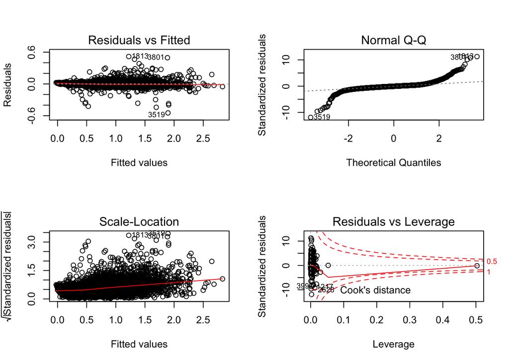

```r
# the VIF has come down from 40 to 10 after removing DIA from the equation


par(mfrow=c(2,2))#creating graph 4by4
plot(model_all2)#ploitng graph for model_all2

X<-ab2[,2:9]#pair-wise correlation among the explanatory variables.
library(GGally)
```

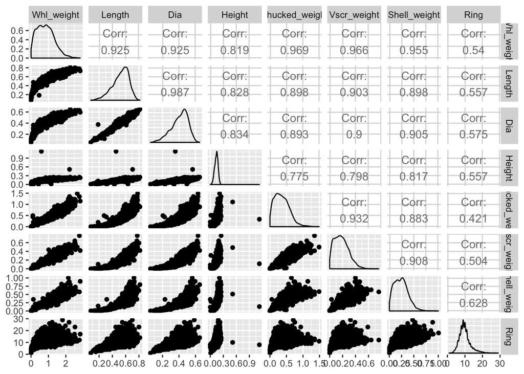

```r
ggpairs(X)#graph
```

```r
library(corpcor)
#Meaning of r values (+/- small, +/- medium, +/- high): check in the PPT
cov(X, use = "everything")
```

```
##                Whl_weight      Length         Dia      Height
## Whl_weight     0.24048139 0.054490708 0.045038182 0.016803471
## Length         0.05449071 0.014422308 0.011760825 0.004156912
## Dia            0.04503818 0.011760825 0.009848551 0.003460547
## Height         0.01680347 0.004156912 0.003460547 0.001749503
## Shucked_weight 0.10551803 0.023934945 0.019674202 0.007194887
## Vscr_weight    0.05194616 0.011887230 0.009787295 0.003660167
## Shell_weight   0.06521587 0.015007172 0.012506637 0.004758900
## Ring           0.85440854 0.215561736 0.183871673 0.075178650
##                Shucked_weight Vscr_weight Shell_weight        Ring
## Whl_weight        0.105518032 0.051946163   0.06521587  0.85440854
## Length            0.023934945 0.011887230   0.01500717  0.21556174
## Dia               0.019674202 0.009787295   0.01250664  0.18387167
## Height            0.007194887 0.003660167   0.00475890  0.07517865
## Shucked_weight    0.049267551 0.022674901   0.02727096  0.30120373
## Vscr_weight       0.022674901 0.012015284   0.01384956  0.17805721
## Shell_weight      0.027270956 0.013849561   0.01937738  0.28166335
## Ring              0.301203734 0.178057215   0.28166335 10.39526595
```

```r
round(cor2pcor(cov(X)),3)
```

```
##        [,1]   [,2]   [,3]   [,4]   [,5]   [,6]   [,7]   [,8]
## [1,]  1.000 -0.011  0.007 -0.003  0.829  0.626  0.753  0.192
## [2,] -0.011  1.000  0.894  0.028  0.071  0.088 -0.029 -0.013
## [3,]  0.007  0.894  1.000  0.104  0.017 -0.025  0.098  0.092
## [4,] -0.003  0.028  0.104  1.000  0.009  0.062  0.090  0.117
## [5,]  0.829  0.071  0.017  0.009  1.000 -0.291 -0.539 -0.355
## [6,]  0.626  0.088 -0.025  0.062 -0.291  1.000 -0.314 -0.116
## [7,]  0.753 -0.029  0.098  0.090 -0.539 -0.314  1.000  0.116
## [8,]  0.192 -0.013  0.092  0.117 -0.355 -0.116  0.116  1.000
```

```r
#Farrar – Glauber Test
library(mctest)
omcdiag(X,ab$Whl_weight)
```

```
##
## Call:
## omcdiag(x = X, y = ab$Whl_weight)
##
##
## Overall Multicollinearity Diagnostics
##
##                        MC Results detection
## Determinant |X'X|:         0.0000         1
## Farrar Chi-Square:     67813.5066         1
## Red Indicator:             0.8199         1
## Sum of Lambda Inverse:   274.0741         1
## Theil's Method:            0.0595         0
## Condition Number:        112.9387         1
##
## 1 --> COLLINEARITY is detected by the test
## 0 --> COLLINEARITY is not detected by the test
```

```r
imcdiag(X,ab$Whl_weight)
```

```
##
## Call:
## imcdiag(x = X, y = ab$Whl_weight)
##
##
## All Individual Multicollinearity Diagnostics Result
##
##                     VIF    TOL         Wi         Fi Leamer CVIF Klein
## Whl_weight     113.7807 0.0088 67168.9781 78382.6046 0.0937    0     0
## Length          40.7791 0.0245 23691.2773 27646.4534 0.1566    0     0
## Dia             42.2035 0.0237 24539.6202 28636.4242 0.1539    0     0
## Height           3.6098 0.2770  1554.3028  1813.7882 0.5263    0     0
## Shucked_weight  32.4528 0.0308 18732.3967 21859.7050 0.1755    0     0
## Vscr_weight     17.5827 0.0569  9876.1831 11524.9774 0.2385    0     0
## Shell_weight    21.5485 0.0464 12238.1224 14281.2342 0.2154    0     0
## Ring             2.1170 0.4724   665.2439   776.3041 0.6873    0     0
##
## 1 --> COLLINEARITY is detected by the test
## 0 --> COLLINEARITY is not detected by the test
##
## Length , Dia , Height , Shucked_weight , Vscr_weight , Shell_weight , Ring , coefficient(s) are non-significant may be due to multicollinearity
##
## R-square of y on all x: 1
##
## * use method argument to check which regressors may be the reason of collinearity
## ===================================
```

```r
#In R, there are several packages for getting the partial correlation coefficients along with the t- test for checking their significance level.
library(ppcor)
pcor(X, method = "pearson")
```

```
## $estimate
##              [,1]        [,2]         [,3]         [,4]         [,5]
## [1,]  1.000000000 -0.01106416  0.006546113 -0.002565473  0.828969959
## [2,] -0.011064158  1.00000000  0.893651960  0.028499868  0.070595591
## [3,]  0.006546113  0.89365196  1.000000000  0.104013805  0.016522218
## [4,] -0.002565473  0.02849987  0.104013805  1.000000000  0.008799232
## [5,]  0.828969959  0.07059559  0.016522218  0.008799232  1.000000000
## [6,]  0.625744527  0.08831939 -0.024742119  0.062157178 -0.291379771
## [7,]  0.752829899 -0.02881030  0.098491647  0.089576624 -0.538916093
## [8,]  0.191852615 -0.01334025  0.092106282  0.117489556 -0.355423161
##             [,6]        [,7]        [,8]
## [1,]  0.62574453  0.75282990  0.19185262
## [2,]  0.08831939 -0.02881030 -0.01334025
## [3,] -0.02474212  0.09849165  0.09210628
## [4,]  0.06215718  0.08957662  0.11748956
```

[output cut: 53 more lines]

```r
#finding corelation among all the variables. removing the column1 and rounding the decimel to 3.
#round(cor(ab[,-1]),3)
#corelation graph
library(corrplot)
correlations1 <-round(cor(ab2[,-1],method = c("pearson")),3)#removing the first column due to not integer.
#corrplot(correlations1, method="circle", type="lower",  sig.level = 0.01, insig = "blank")
corrplot(correlations1, method="number", type="lower",  sig.level = 0.01, insig = "blank")# here colrelation is given as number ; method = number

correlations2 <- round(cor(ab2[,-c(1,2,3,4,5)],method = c("pearson")),3)# removing the first 5 column, as VIF is more for the shucked, vscr and shell weight
#corrplot(correlations2, method="circle", type="lower",  sig.level = 0.01, insig = "blank")
corrplot(correlations2, method="number", type="lower",  sig.level = 0.01, insig = "blank")## here colrelation is given as number ; method = number

library(car)
vif(model_all2)
```

[output not shown]

```
##           Ring         Length         Height Shucked_weight    Vscr_weight
##       2.020610       8.211232       3.570701      10.135891      10.690590
##   Shell_weight
##       9.105357
```

```r
#Vscr_weight has the heighest VIF value, removing it.
#after removing Vscr_weight, Ajusted r2 is reduced from 0.9912 to 0.9855
model_all3 = lm(Whl_weight ~ Ring +Length+ Height + Shucked_weight +Shell_weight, data = ab2)
summary(model_all3)
```

```
##
## Call:
## lm(formula = Whl_weight ~ Ring + Length + Height + Shucked_weight +
##     Shell_weight, data = ab2)
##
## Residuals:
##      Min       1Q   Median       3Q      Max
## -0.53845 -0.02710 -0.00268  0.02245  0.58385
##
## Coefficients:
##                  Estimate Std. Error t value Pr(>|t|)
## (Intercept)    -0.0894917  0.0070839 -12.633  < 2e-16 ***
## Ring            0.0040392  0.0004024  10.038  < 2e-16 ***
## Length          0.1455839  0.0214214   6.796 1.23e-11 ***
## Height          0.1215584  0.0411139   2.957  0.00313 **
## Shucked_weight  1.2537447  0.0111762 112.180  < 2e-16 ***
## Shell_weight    1.3997802  0.0188353  74.317  < 2e-16 ***
## ---
## Signif. codes:  0 '***' 0.001 '**' 0.01 '*' 0.05 '.' 0.1 ' ' 1
##
## Residual standard error: 0.05898 on 4171 degrees of freedom
## Multiple R-squared:  0.9856, Adjusted R-squared:  0.9855
## F-statistic: 5.691e+04 on 5 and 4171 DF,  p-value: < 2.2e-16
```

```r
car:: vif(model_all3)
```

```
##           Ring         Length         Height Shucked_weight   Shell_weight
##       2.020594       7.945488       3.550449       7.388194       8.253326
```

```r
#height is less significant compared to others.Adjusted R-squared:  0.9855
model_all4 = lm(Whl_weight ~ Ring +Length + Shucked_weight +Shell_weight, data = ab)
summary(model_all4)
```

```
##
## Call:
## lm(formula = Whl_weight ~ Ring + Length + Shucked_weight + Shell_weight,
##     data = ab)
##
## Residuals:
##      Min       1Q   Median       3Q      Max
## -0.53969 -0.02718 -0.00222  0.02222  0.58396
##
## Coefficients:
##                  Estimate Std. Error t value Pr(>|t|)
## (Intercept)    -0.0869734  0.0070391 -12.356  < 2e-16 ***
## Ring            0.0041950  0.0003993  10.507  < 2e-16 ***
## Length          0.1640315  0.0205116   7.997 1.64e-15 ***
## Shucked_weight  1.2558920  0.0111629 112.506  < 2e-16 ***
## Shell_weight    1.4100597  0.0185288  76.101  < 2e-16 ***
## ---
## Signif. codes:  0 '***' 0.001 '**' 0.01 '*' 0.05 '.' 0.1 ' ' 1
##
## Residual standard error: 0.05903 on 4172 degrees of freedom
## Multiple R-squared:  0.9855, Adjusted R-squared:  0.9855
## F-statistic: 7.1e+04 on 4 and 4172 DF,  p-value: < 2.2e-16
```

```r
car:: vif(model_all4)
```

```
##           Ring         Length Shucked_weight   Shell_weight
##       1.985925       7.271410       7.356996       7.972114
```

```r
## now All the independent values have high significance P values.Adjusted R-squared:  0.9855
```

[figure not shown]

### (c) Do (i) scatter plot, (ii) conditional expectation (mean) plot

```r
require(dplyr)
```

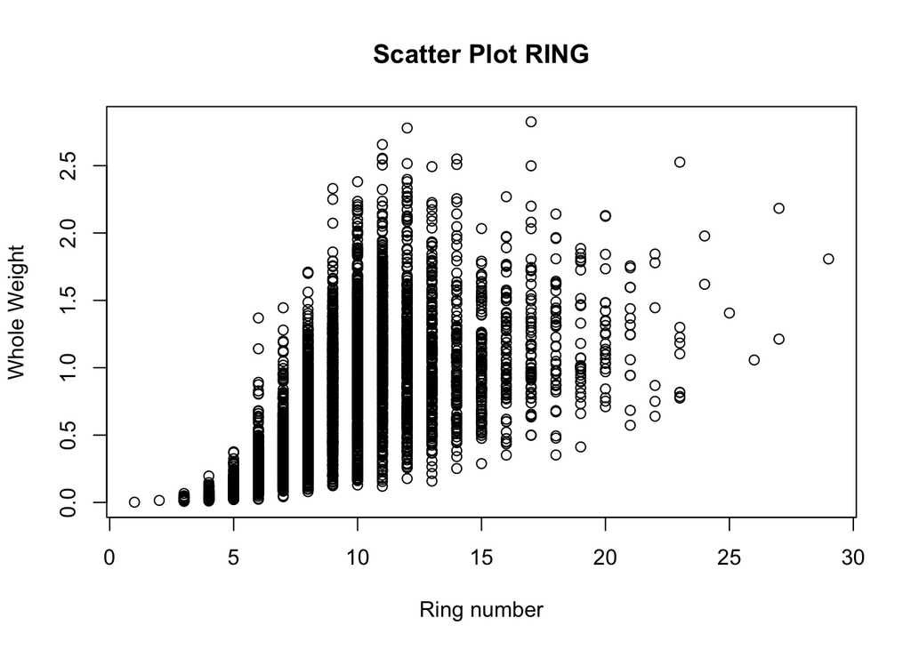

```r
plot(ab$Ring,ab$Whl_weight,xlab = "Ring number",ylab = "Whole Weight",main = "Scatter Plot RING")
```

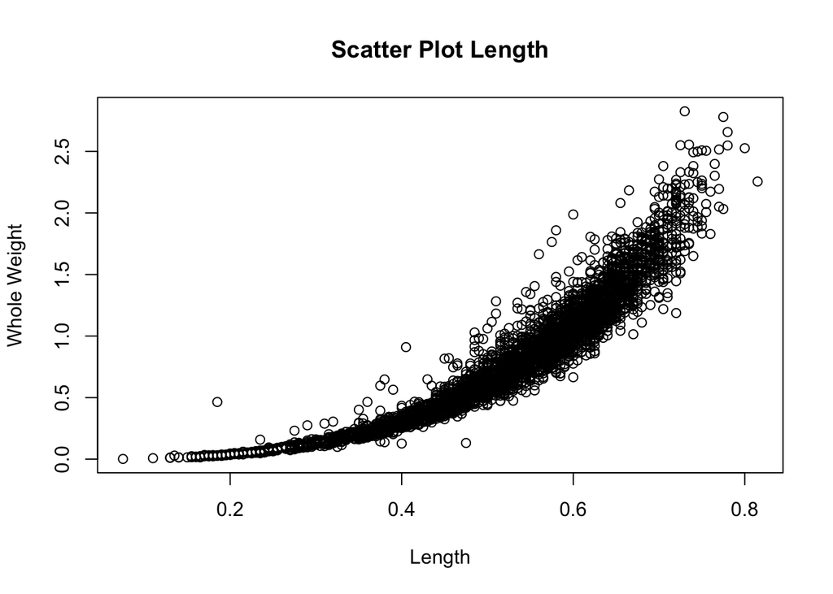

```r
plot(ab$Length,ab$Whl_weight,xlab = "Length",ylab = "Whole Weight",main = "Scatter Plot Length")
```

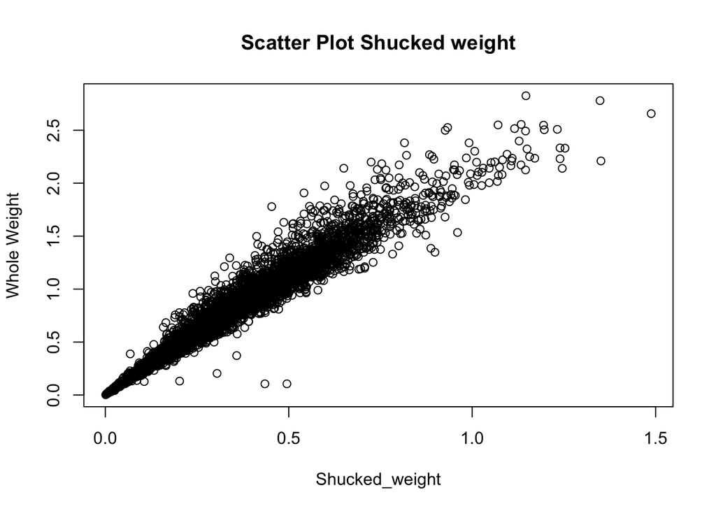

```r
plot(ab$Shucked_weight,ab$Whl_weight,xlab = "Shucked_weight",ylab = "Whole Weight",main = "Scatter Plot Shucked weight")
```

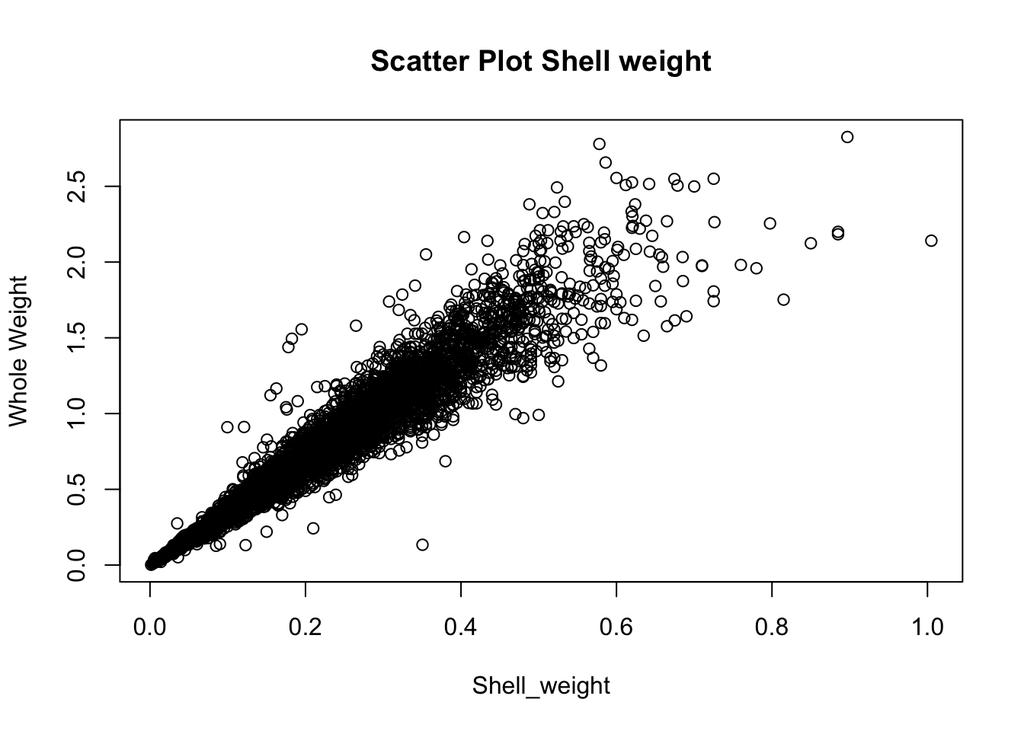

```r
plot(ab$Shell_weight,ab$Whl_weight,xlab = "Shell_weight",ylab = "Whole Weight",main = "Scatter Plot Shell weight")
```

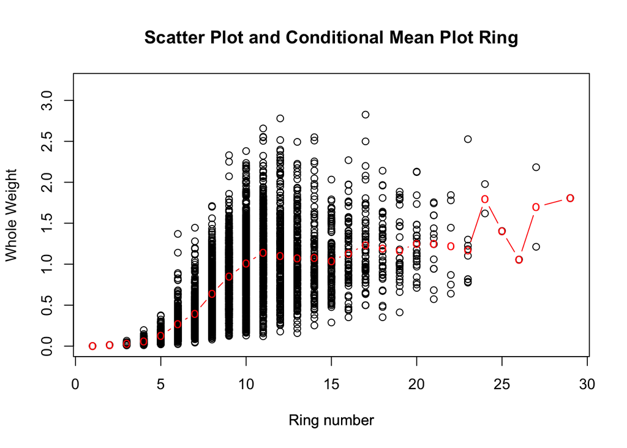

```r
# ### (c) Do (ii) conditional expectation (mean) plot
require(dplyr)

plot(ab$Ring,ab$Whl_weight,xlab = "Ring number",ylim=c(0,3.2),ylab = "Whole Weight",main = "Scatter Plot and Conditional Mean Plot Ring")

par(new=TRUE)
summ = summarize(group_by(ab,Ring),cond_exp = mean(Whl_weight))
plot(summ$Ring,summ$cond_exp,xlab = "Ring number",main = "",type = "b", ylab="", axes=FALSE,ylim=c(0,3.2), col='red', pch='o')
```

### (d) Based on scatter plot, what is a visual estimate of the Pearson correlation coefficient between the dependent variable and the independent variable?

```r
paste('Pearson correlation between Ring and Whl_weight = ', round(cor(ab$Ring,ab$Whl_weight),4))# this is to compare scatter plot based correlation of original highly dispersed data
```

```
## [1] "Pearson correlation between Ring and Whl_weight =  0.5404"
```

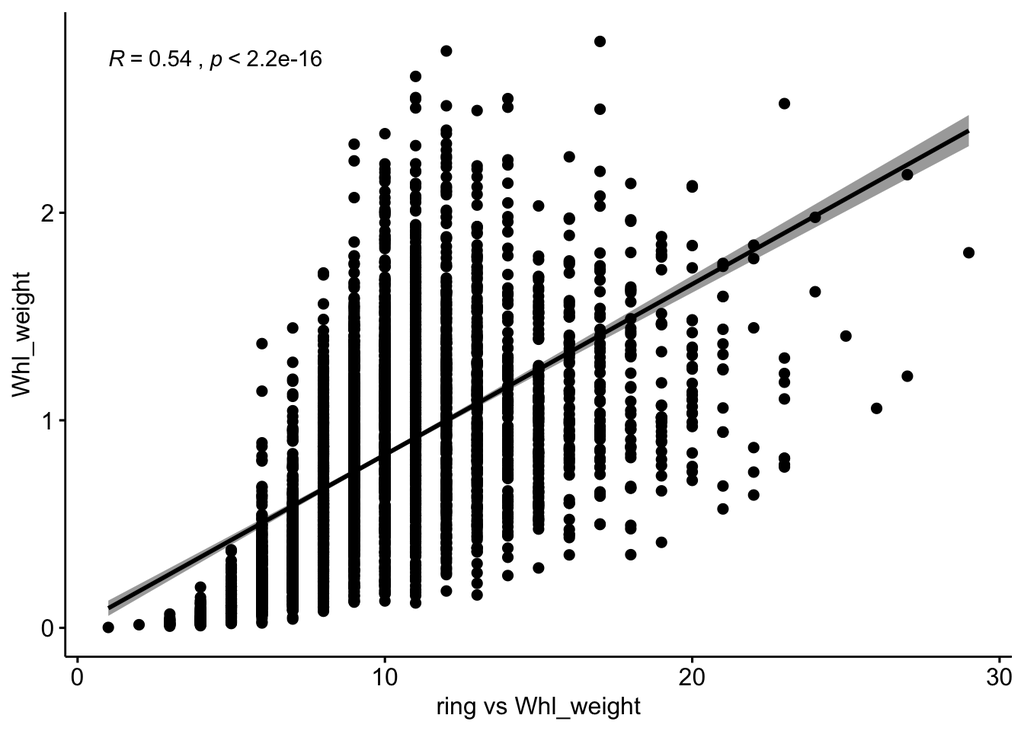

```r
##paste('Pearson correlation between Ring and E[Whl_weight|Ring] = ', round(cor(summ$Ring,summ$cond_exp),4)) # this is based on conditional expectation values and the dependent variable; Though we are really modeling conditional expectations, the error in the original observations also should be part of the correlation and the model!##

## here we are ploting the ggscatter plot : visual estimate of the Pearson correlation coefficient
library("ggpubr")
ggscatter(ab, x = "Ring", y = "Whl_weight",
          add = "reg.line", conf.int = TRUE,
          cor.coef = TRUE, cor.method = "pearson",
          xlab = "ring vs Whl_weight", ylab = "Whl_weight")
```

```r
# here check the r console for ring and whl_weight = 0.5404
# and the ggscatter plot also gived same R=0.54 for ring and whl_weight.
```

### (e) Hand draw the best line that passes through the conditional mean plot, after you print out the R based output

```r
# Let us try this with abline to see how closely our intuition matched with the abline (which is a regression line)

library(corpcor)
cov(X, use = "everything")
```

```
##                Whl_weight      Length         Dia      Height
## Whl_weight     0.24048139 0.054490708 0.045038182 0.016803471
## Length         0.05449071 0.014422308 0.011760825 0.004156912
## Dia            0.04503818 0.011760825 0.009848551 0.003460547
## Height         0.01680347 0.004156912 0.003460547 0.001749503
## Shucked_weight 0.10551803 0.023934945 0.019674202 0.007194887
## Vscr_weight    0.05194616 0.011887230 0.009787295 0.003660167
## Shell_weight   0.06521587 0.015007172 0.012506637 0.004758900
## Ring           0.85440854 0.215561736 0.183871673 0.075178650
##                Shucked_weight Vscr_weight Shell_weight        Ring
## Whl_weight        0.105518032 0.051946163   0.06521587  0.85440854
## Length            0.023934945 0.011887230   0.01500717  0.21556174
## Dia               0.019674202 0.009787295   0.01250664  0.18387167
## Height            0.007194887 0.003660167   0.00475890  0.07517865
## Shucked_weight    0.049267551 0.022674901   0.02727096  0.30120373
## Vscr_weight       0.022674901 0.012015284   0.01384956  0.17805721
## Shell_weight      0.027270956 0.013849561   0.01937738  0.28166335
## Ring              0.301203734 0.178057215   0.28166335 10.39526595
```

```r
round(cor2pcor(cov(X)),3)
```

```
##        [,1]   [,2]   [,3]   [,4]   [,5]   [,6]   [,7]   [,8]
## [1,]  1.000 -0.011  0.007 -0.003  0.829  0.626  0.753  0.192
## [2,] -0.011  1.000  0.894  0.028  0.071  0.088 -0.029 -0.013
## [3,]  0.007  0.894  1.000  0.104  0.017 -0.025  0.098  0.092
## [4,] -0.003  0.028  0.104  1.000  0.009  0.062  0.090  0.117
## [5,]  0.829  0.071  0.017  0.009  1.000 -0.291 -0.539 -0.355
## [6,]  0.626  0.088 -0.025  0.062 -0.291  1.000 -0.314 -0.116
## [7,]  0.753 -0.029  0.098  0.090 -0.539 -0.314  1.000  0.116
## [8,]  0.192 -0.013  0.092  0.117 -0.355 -0.116  0.116  1.000
```

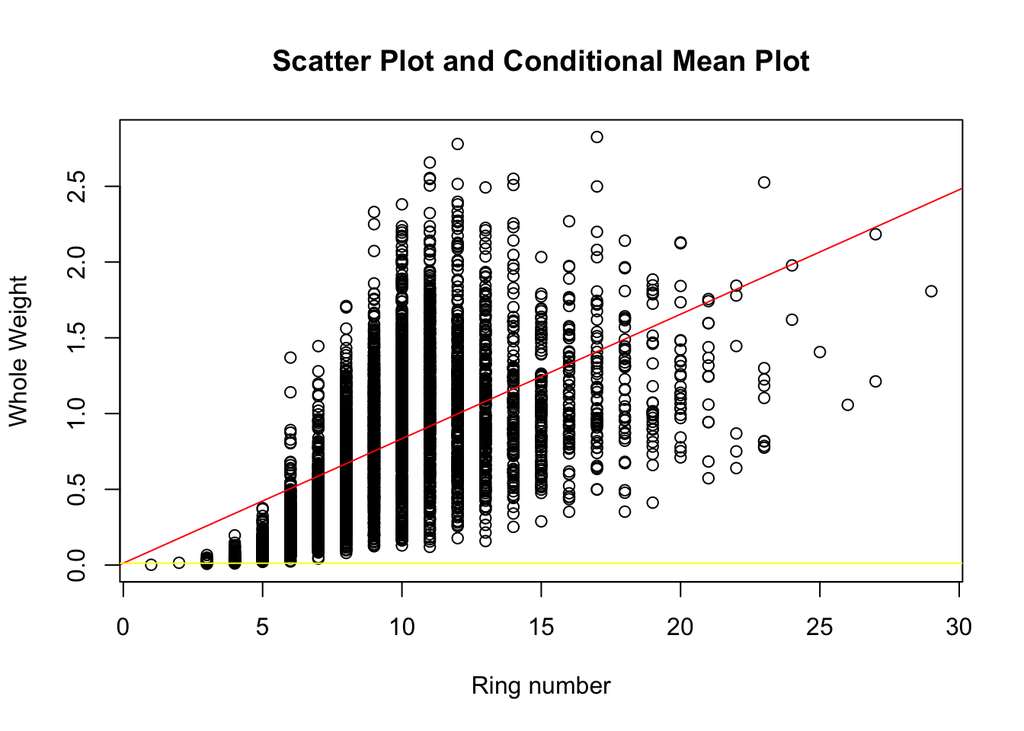

```r
#here thy are usung ABline for
plot(ab$Ring,ab$Whl_weight,xlab = "Ring number",ylab = "Whole Weight",main = "Scatter Plot and Conditional Mean Plot")
z<- lm(Whl_weight ~ Ring,data = ab)
abline(z,col="red")
#abline(coef = coef(z), col ="blue")
abline(a = coef(z), b = 0.0, col = "yellow")#here making the slope to zero
```

```r
z # now didplaying the  model
```

```
##
## Call:
## lm(formula = Whl_weight ~ Ring, data = ab)
##
## Coefficients:
## (Intercept)         Ring
##     0.01227      0.08219
```

```r
z_smry <- summary(z)
paste('Adj.R squar value of Whl_weight ~ Ring = ',z_smry$adj.r.squared)
```

```
## [1] "Adj.R squar value of Whl_weight ~ Ring =  0.291851427118235"
```

### (f) Visually estimate the slope and intercept.

#intercept is on 0.01227 #slope is on 0.08219 #

# Assignment 2

### (a) Use R to do the regression model that is representative of the (e) in Assignment 1; compare the results you got from the R output to your visual judgements you made in Assignment (1) (f).

```r
model = lm(Whl_weight ~ Ring,data = ab)
summary(model)
```

```
##
## Call:
## lm(formula = Whl_weight ~ Ring, data = ab)
##
## Residuals:
##      Min       1Q   Median       3Q      Max
## -1.18050 -0.30388 -0.06831  0.26612  1.78092
##
## Coefficients:
##             Estimate Std. Error t value Pr(>|t|)
## (Intercept) 0.012272   0.020685   0.593    0.553
## Ring        0.082192   0.001981  41.498   <2e-16 ***
## ---
## Signif. codes:  0 '***' 0.001 '**' 0.01 '*' 0.05 '.' 0.1 ' ' 1
##
## Residual standard error: 0.4127 on 4175 degrees of freedom
## Multiple R-squared:  0.292,  Adjusted R-squared:  0.2919
## F-statistic:  1722 on 1 and 4175 DF,  p-value: < 2.2e-16
```

### (b) Do different single variable models, depending on as many number of independent variables you have in your data set

```r
model_1 = lm(Whl_weight ~ Dia,data = ab)
Model_1_smry <-summary(model_1)#assiging the summary to a variable to display result

model_2 = lm(Whl_weight ~ Length,data = ab)
summary(model_2)
```

```
##
## Call:
## lm(formula = Whl_weight ~ Length, data = ab)
##
## Residuals:
##      Min       1Q   Median       3Q      Max
## -0.51214 -0.12372 -0.04076  0.07928  1.21841
##
## Coefficients:
##             Estimate Std. Error t value Pr(>|t|)
## (Intercept) -1.15102    0.01289  -89.32   <2e-16 ***
## Length       3.77822    0.02397  157.61   <2e-16 ***
## ---
## Signif. codes:  0 '***' 0.001 '**' 0.01 '*' 0.05 '.' 0.1 ' ' 1
##
## Residual standard error: 0.186 on 4175 degrees of freedom
## Multiple R-squared:  0.8561, Adjusted R-squared:  0.8561
## F-statistic: 2.484e+04 on 1 and 4175 DF,  p-value: < 2.2e-16
```

```r
model_3 = lm(Whl_weight ~ Height,data = ab)
summary(model_3)
```

```
##
## Call:
## lm(formula = Whl_weight ~ Height, data = ab)
##
## Residuals:
##     Min      1Q  Median      3Q     Max
## -9.7481 -0.1488 -0.0345  0.1150  1.5237
##
## Coefficients:
##             Estimate Std. Error t value Pr(>|t|)
## (Intercept) -0.51127    0.01516  -33.73   <2e-16 ***
## Height       9.60471    0.10406   92.30   <2e-16 ***
## ---
## Signif. codes:  0 '***' 0.001 '**' 0.01 '*' 0.05 '.' 0.1 ' ' 1
##
## Residual standard error: 0.2813 on 4175 degrees of freedom
## Multiple R-squared:  0.6711, Adjusted R-squared:  0.671
## F-statistic:  8520 on 1 and 4175 DF,  p-value: < 2.2e-16
```

```r
model_4 = lm(Whl_weight ~ Shucked_weight,data = ab)
model_4_smry <-summary(model_4)


model_5 = lm(Whl_weight ~ Vscr_weight,data = ab)
summary(model_5)
```

```
##
## Call:
## lm(formula = Whl_weight ~ Vscr_weight, data = ab)
##
## Residuals:
##      Min       1Q   Median       3Q      Max
## -0.92261 -0.06096 -0.01540  0.05741  0.96605
##
## Coefficients:
##             Estimate Std. Error t value Pr(>|t|)
## (Intercept) 0.047975   0.003761   12.76   <2e-16 ***
## Vscr_weight 4.323340   0.017804  242.83   <2e-16 ***
## ---
## Signif. codes:  0 '***' 0.001 '**' 0.01 '*' 0.05 '.' 0.1 ' ' 1
##
## Residual standard error: 0.1261 on 4175 degrees of freedom
## Multiple R-squared:  0.9339, Adjusted R-squared:  0.9339
## F-statistic: 5.897e+04 on 1 and 4175 DF,  p-value: < 2.2e-16
```

```r
model_6 = lm(Whl_weight ~ Shell_weight,data = ab)
summary(model_6)
```

```
##
## Call:
## lm(formula = Whl_weight ~ Shell_weight, data = ab)
##
## Residuals:
##      Min       1Q   Median       3Q      Max
## -1.26634 -0.06038 -0.01559  0.06219  0.87477
##
## Coefficients:
##              Estimate Std. Error t value Pr(>|t|)
## (Intercept)  0.024941   0.004453   5.601 2.27e-08 ***
## Shell_weight 3.365566   0.016109 208.928  < 2e-16 ***
## ---
## Signif. codes:  0 '***' 0.001 '**' 0.01 '*' 0.05 '.' 0.1 ' ' 1
##
## Residual standard error: 0.1449 on 4175 degrees of freedom
## Multiple R-squared:  0.9127, Adjusted R-squared:  0.9127
## F-statistic: 4.365e+04 on 1 and 4175 DF,  p-value: < 2.2e-16
```

```r
paste('Adj.R squar value of Whl_weight ~ Shucked_weight = ',model_4_smry$adj.r.squared)
```

```
## [1] "Adj.R squar value of Whl_weight ~ Shucked_weight =  0.93973250761561"
```

### (c) Which model is most predictive and why? Why your expectation of the best one variable regression did not match with the actual computations based best model

Adjusted R-squared: 0.9397 - lm(formula = Whl_weight ~ Shucked_weight, data = ab); the Whole weight vs shucked weight is more predictive with higest Adjusted rsquare.

### (d) Having selected the best single variable model, add the second best variable to the model. What happened to the estimate of the first model. Does it make sense?

```r
model_7 = lm(Whl_weight ~ Shucked_weight + Vscr_weight,data = ab)
summary(model_7)
```

```
##
## Call:
## lm(formula = Whl_weight ~ Shucked_weight + Vscr_weight, data = ab)
##
## Residuals:
##      Min       1Q   Median       3Q      Max
## -0.66707 -0.03724 -0.01378  0.02357  0.61676
##
## Coefficients:
##                Estimate Std. Error t value Pr(>|t|)
## (Intercept)    0.026522   0.002557   10.37   <2e-16 ***
## Shucked_weight 1.156049   0.016372   70.61   <2e-16 ***
## Vscr_weight    2.141679   0.033152   64.60   <2e-16 ***
## ---
## Signif. codes:  0 '***' 0.001 '**' 0.01 '*' 0.05 '.' 0.1 ' ' 1
##
## Residual standard error: 0.08514 on 4174 degrees of freedom
## Multiple R-squared:  0.9699, Adjusted R-squared:  0.9699
## F-statistic: 6.718e+04 on 2 and 4174 DF,  p-value: < 2.2e-16
```

### (f) when is it likey to create a situation, when the second variale is added, the regression coefficient of the first variable changes sign of the coefficent?